# Cost of Weather in Lives and Dollars

Jerad Acosta

October 26, 2014

## The Cost of Weather in Lives and Dollars

### Synopsis

The data analyzed herein comes from the NCDC who collects if from the National Weather Service which collects and receives the data from a variety of sources.

This data contains myriad information on weather data from accross the US. This includes but is not limited to: locations, type of weather, time, as well as tides and other natural phenomina.

Of greatest significance to this report is the collection of data on the impact weather has on both the populations health and the economy as a whole.

To address this question variables such as Fatalities and Injuries were collected and organized according to source and magnitude.

Additionally, damages to property, required storm preperation and other factors such as crop destruction and related costs from delayed processes.

### Data Processing

Load Data and libraries

```r
library(plyr)
library(dplyr)
```

```r
library(ggplot2)
library(reshape2)
library(grid)
library(gridExtra)
data <- read.csv("repdata-data-StormData.csv")
```

## Search for significant factors of damage to population health

**Subset data to contrain only factors of interest with respect to population health**

```r
health <- select(data, EVTYPE, FATALITIES, INJURIES)
```

Find range in Fatalities and Injuries to deduce most significant events

```r
range(health$FATALITIES)
```

```
## [1]   0 583
```

```r
sum(health$FATALITIES)
```

```
## [1] 15145
```

```r
range(health$INJURIES)
```

```
## [1]    0 1700
```

```r
sum(health$INJURIES)
```

```
## [1] 140528
```

```r
healthmelt <- melt(health, id=c("EVTYPE"), measure.vars=c("FATALITIES","INJURIES"))
healthsum <- dcast(healthmelt, EVTYPE ~ variable, sum)
```

```r
top.fatal <- arrange(healthsum, desc(FATALITIES))
top.fatal <- filter(top.fatal, FATALITIES > 1)
top.injure <- arrange(healthsum, desc(INJURIES))
top.injure <- filter(top.injure, INJURIES > 1)
```

**Use graph to see how data is distributed accross categorical data such as Weather Events**

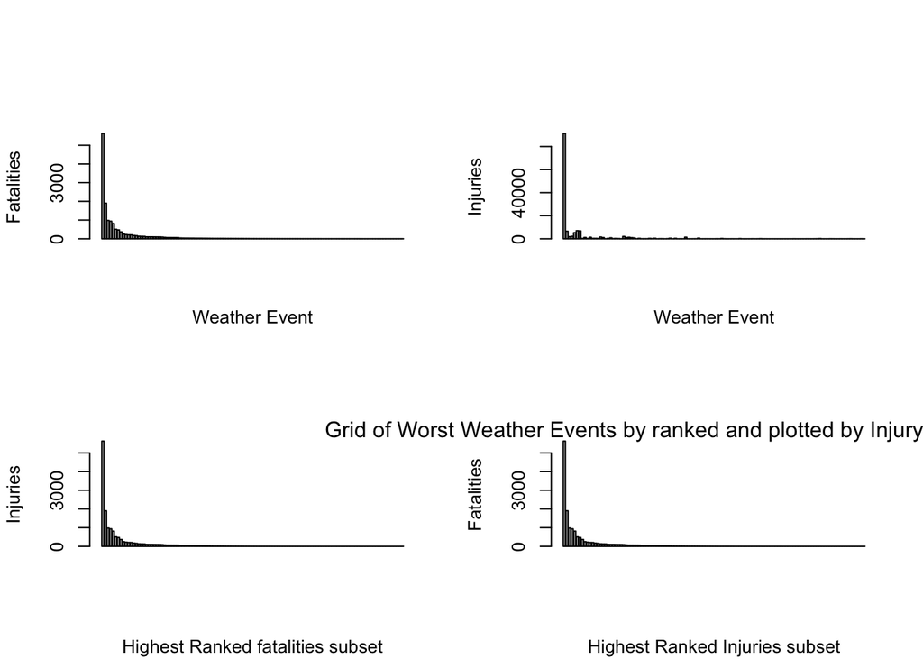

```r
par(mfcol = c(2,2), oma = c(0,0,2,0))
barplot(top.fatal$FATALITIES, xlab = "Weather Event", ylab = "Fatalities")
barplot(top.fatal$FATALITIES, ylab = "Injuries",
        sub = "Highest Ranked fatalities subset")
barplot(top.fatal$INJURIES, xlab = "Weather Event", ylab = "Injuries")
barplot(top.fatal$FATALITIES, ylab = "Fatalities",
        sub = "Highest Ranked Injuries subset")
mtext("Grid of Worst Weather Events by ranked and plotted by Injury and Fatality count")
```

```r
par(mfrow = c(1,1))
```

From the data here we can see that the majority of the damage is done by a few significant Weather Event Types. Too look Closer at them we can subset and graph with labels

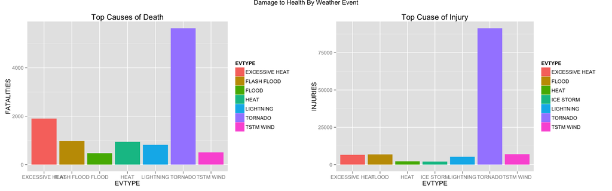

```r
# Top Fatal Weather Events
fat <- qplot(EVTYPE, FATALITIES, data = top.fatal[1:7,], fill = EVTYPE,
             geom = "bar", stat="identity", main = "Top Causes of Death")
# Top Injuries Weather Events
inj <- qplot(EVTYPE, INJURIES, data = top.injure[1:7,], fill = EVTYPE,
             geom = "bar", stat="identity", main = "Top Cuase of Injury")
grid.arrange(fat, inj, ncol = 2, main = "Damage to Health By Weather Event")
```

### Results

From this we can conclude that the most devistating of all weather events to the health of citizens in the United States is by and Far Tornados. So much so, that it is on a different scale of magnitude.

It is also worth noting that Excessive Heat shows up quite significantly and that floods show up in two forms of *flooding* and *flash flooding*